# SI 630: Homework 1 - Classification (Sangho Eum)

## TASK 2: Logistic Regression

## Conclusion

- Given some choice of β to make predictions, we want to use the difference in our prediction Yˆ from the ground truth Y to update β. The gradient of the log likelihood tells us which direction (positive or negative) to make the update and how large the update should be. Write a function compute gradient to compute the gradient. Note that we can compute the whole gradient using ∇ l l = X T ( Y − Yˆ ) Note that Y is a binary vector with our ground truth (i.e., the training data labels) and Yˆ is the binary vector with the predictions. To get a sense of why this works, think about what gradient will equal if our prediction for item i, Yˆ is the same as the ground truth Y ; if we ii use this gradient to update our weight for βi, what effect will it have?

-> Gradient is zero, so it does not make an impact.

- Train your model on the training data learning rate=5e-5 (i.e., a very small number) and num steps = 300000. Make a plot of the log-likelihood every 10,000 steps. Did the model converge at some point (i.e., does the log likelihood remain stable)?

-> Yes, it converges to some point. It will be getting more stable.

- Change the learning rate to a much larger and much smaller value and repeat the train- ing procedure for each. Plot all three curves together and describe what you observe. You’re welcome (encouraged, even!) to try additional learning rates. If your model is very slow or if it converges quickly, you can also reduce the number of steps for this question.

-> See my graph below. I created curves with learning rate 5e-3, 5e-5, 5e-7 respectively.

- After training on the training data, use your logistic regression classifier to make predictions on the validation dataset and report your performance using the F1.

-> 0.9600 with 5e-5 learning rate

- Submit your best model’s predictions on the test data to Kaggle.

-> I have submitted mine and score is 0.95979

```python
# import library
import csv
from sklearn.metrics import f1_score
import matplotlib.pyplot as plt
import re
import numpy as np
from scipy.sparse import csr_matrix, hstack
import logging, sys
import math
```

```python
# load data
dat = []
dev = []
stop_words = []
with open('train.tsv') as tsvfile:
  reader = csv.DictReader(tsvfile, dialect='excel-tab', quoting=csv.QUOTE_NONE)
  for i in reader:
      dat.append(i)

with open('dev.tsv') as tsvfile:
  reader2 = csv.DictReader(tsvfile, dialect='excel-tab', quoting=csv.QUOTE_NONE)
  for i in reader2:
      dev.append(i)

with open('stopwords.txt', 'r') as file:
    for line in file.readlines():
        stop_words.append(line.strip())
```

```python
# tokenize % better tokenize functions
def tokenize(text):
    return text.split()

def better_tokenize(text):
    text = text.lower()
    text = re.sub(r"(@[a-zA-Z0-9_]+)|(\w+:\/\/\S+)", " ", text)
    text = re.sub('[^A-Za-z0-9 ]+', '', text)
    features = text.split()
    filtered_features = []
    for feature in features:
        if feature not in stop_words:
            filtered_features.append(feature)
    return filtered_features
```

```python
# Create matrix function
def create_matrix(lst):
    indptr = [0]
    indices = []
    data = []
    vocabulary = {}
    y_true = []

    for i in lst:
        y_true.append(int(i['class']))

        text = better_tokenize(i['text'])
        for k in text:
            index = vocabulary.setdefault(k, len(vocabulary))
            indices.append(index)
            data.append(1)
        indptr.append(len(indices))
    a = csr_matrix((data, indices, indptr))
    return [a, np.array([y_true]).T, vocabulary]
```

```python
# Sigmiod function
def sigmoid(z):
    return 1/(1+np.exp(-z))
```

```python
# Log likely function
def log_likelihood(x, yt, w):
    scores = x.dot(w)
    ll = np.sum(yt * scores - np.log(1 + np.exp(scores)))
    return ll
```

```python
# logistic regression function
def logistic_regression(x, yt, num_steps, learning_rate, add_intercept = False):
    steps = []
    ll_lst = []

    if add_intercept:
        intercept = np.ones((x.shape[0], 1))
        x = hstack((intercept, x))

    w = np.zeros((x.shape[1], 1))

    for step in range(num_steps):
        scores = x.dot(w)
        predictions = sigmoid(scores)
        output_error_signal = yt - predictions
        gradient = x.T.dot(output_error_signal)
        w += learning_rate * gradient

        if step % 10000 == 0:
            steps.append(step)
            ll = log_likelihood(x, yt, w)
            ll_lst.append(ll)
            print('step: ',step, '', 'll: ', ll)
    return {'w': w, 'step': steps, 'll': ll_lst}
```

```python
# f1 score function
def f1_check(yte, ytr):
    return f1_score(yte, ytr, average='micro')
```

```python
# Create matrix with train.tsv data set
train_set = create_matrix(dat)
train_x = train_set[0]
train_y = train_set[1]
train_v = train_set[2]
```

```python
# Training with 5e-5 learning rate

w1 = logistic_regression(train_x, train_y, num_steps = 300000, learning_rate = 5e-5, add_intercept = True)
w1_step = w1['step']
w1_ll = w1['ll']
w1_w = w1['w']
```

```
step:  0  ll:  -23640.4861138
step:  10000  ll:  -2492.9016657
step:  20000  ll:  -1864.34605301
step:  30000  ll:  -1537.99864447
step:  40000  ll:  -1328.29354231
step:  50000  ll:  -1179.08053081
step:  60000  ll:  -1066.26790888
step:  70000  ll:  -977.452273711
step:  80000  ll:  -905.454732958
step:  90000  ll:  -845.783101199
step:  100000  ll:  -795.459860928
step:  110000  ll:  -752.415712898
step:  120000  ll:  -715.155447489
step:  130000  ll:  -682.566292938
step:  140000  ll:  -653.80248669
step:  150000  ll:  -628.211395241
step:  160000  ll:  -605.283155875
step:  170000  ll:  -584.61438926
step:  180000  ll:  -565.88120286
step:  190000  ll:  -548.81926086
step:  200000  ll:  -533.209623823
step:  210000  ll:  -518.868980833
step:  220000  ll:  -505.642791388
step:  230000  ll:  -493.400170035
step:  240000  ll:  -482.029828737
step:  250000  ll:  -471.436743555
step:  260000  ll:  -461.539389305
step:  270000  ll:  -452.267458701
step:  280000  ll:  -443.560007047
step:  290000  ll:  -435.363964594
```

```python
# Training with 5e-3 learning rate
w2 = logistic_regression(train_x, train_y, num_steps = 300000, learning_rate = 5e-3, add_intercept = True)
w2_ll = w2['ll']
w2_w = w2['w']
```

```
step:  0  ll:  -25833.7984387
step:  10000  ll:  -240.01703467
step:  20000  ll:  -187.285802498
step:  30000  ll:  -165.943090628
step:  40000  ll:  -153.790974512
step:  50000  ll:  -145.698162286
step:  60000  ll:  -139.815140252
step:  70000  ll:  -135.294998801
step:  80000  ll:  -131.687388317
step:  90000  ll:  -128.725227011
step:  100000  ll:  -126.238294247
step:  110000  ll:  -124.11262634
step:  120000  ll:  -122.268855315
step:  130000  ll:  -120.64982892
step:  140000  ll:  -119.213210368
step:  150000  ll:  -117.926893389
step:  160000  ll:  -116.766064014
step:  170000  ll:  -115.711246373
step:  180000  ll:  -114.746948395
step:  190000  ll:  -113.860690449
step:  200000  ll:  -113.042296695
step:  210000  ll:  -112.283375602
step:  220000  ll:  -111.576937068
step:  230000  ll:  -110.917106405
step:  240000  ll:  -110.298906388
step:  250000  ll:  -109.718087994
step:  260000  ll:  -109.170997265
step:  270000  ll:  -108.654469945
step:  280000  ll:  -108.16574783
step:  290000  ll:  -107.702412163
```

```python
# Training with 5e-7 learning rate

w3 = logistic_regression(train_x, train_y, num_steps = 300000, learning_rate = 5e-7, add_intercept = True)
w3_ll = w3['ll']
w3_w = w3['w']
```

```
step:  0  ll:  -24821.6880125
step:  10000  ll:  -9658.92336771
step:  20000  ll:  -7959.98748762
step:  30000  ll:  -7122.68819361
step:  40000  ll:  -6583.7430462
step:  50000  ll:  -6193.40669741
step:  60000  ll:  -5891.17591241
step:  70000  ll:  -5646.77790446
step:  80000  ll:  -5442.96793074
step:  90000  ll:  -5269.03377446
step:  100000  ll:  -5117.89561094
step:  110000  ll:  -4984.64984117
step:  120000  ll:  -4865.7723578
step:  130000  ll:  -4758.65327388
step:  140000  ll:  -4661.31094638
step:  150000  ll:  -4572.20873415
step:  160000  ll:  -4490.13342632
step:  170000  ll:  -4414.11215194
step:  180000  ll:  -4343.35410761
step:  190000  ll:  -4277.20875761
step:  200000  ll:  -4215.13524755
step:  210000  ll:  -4156.67962513
step:  220000  ll:  -4101.45760676
step:  230000  ll:  -4049.1413551
step:  240000  ll:  -3999.44920485
step:  250000  ll:  -3952.13758777
step:  260000  ll:  -3906.99461967
step:  270000  ll:  -3863.83495924
step:  280000  ll:  -3822.49565038
step:  290000  ll:  -3782.83273324
```

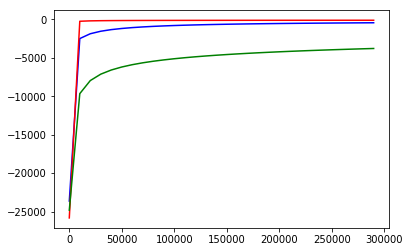

```python
plt.plot(w1_step, w1_ll, 'b')
plt.plot(w1_step, w2_ll, 'r')
plt.plot(w1_step, w3_ll, 'g')
plt.show()
```

```python
def predict(x, w):
    scores = x.dot(w)
    yp = sigmoid(scores)
    ytr = np.around(yp)
    return ytr
```

```python
def predict2(d, w, vocabulary, label = True, add_intercept = False):
    yp = []
    yt = []
    inst =[]

    for i in d:
        inst.append(i['instance_id'])
        if label:
            yt.append(int(i['class']))


        if add_intercept:
            x = np.zeros((1, len(vocabulary)+1))
            x[0, 0] = 1
            text = better_tokenize(i['text'])
            for k in text:
                if k in vocabulary:
                    index = vocabulary[k]
                    x[0, index+1] += 1
        else:
            x = np.zeros((1, len(vocabulary)))
            text = better_tokenize(i['text'])
            for k in text:
                if k in vocabulary:
                    index = vocabulary[k]
                    x[0, index] += 1

        scores = int(predict(x,w))
        yp.append(scores)

    return {'yp': yp, 'yt': yt, 'inst_id': inst}
```

```python
p1 = predict2(dev, w1_w, train_v, label = True, add_intercept = True )
yp1 = p1['yp']
yt1 = p1['yt']

f1 = f1_check(yt1,yp1)
print(f1)
```

```
0.960026797678
```

```python
# With unlabeled files

# Load unlabeled data
testarr =[]
with open('test.unlabeled.tsv') as tsvfile:
    reader3 = csv.DictReader(tsvfile, dialect='excel-tab', quoting=csv.QUOTE_NONE)
    for i in reader3:
        testarr.append(i)
```

```python
p2 = predict2(testarr, w1_w, train_v, label = False, add_intercept = True)
yp2 = p2['yp']
yid2 = p2['inst_id']
```

```python
# expoer csv for Kaggle

with open('kaggle_logist.csv', 'w') as file:
    file.write("instance_id,class\n")
    for i in range(len(yp2)):
        file.write(yid2[i]+","+str(yp2[i])+"\n")
```